# Reproducible Research: Peer Assessment 1

## Loading and preprocessing the data

Since I know I’ll be creating exhibits and needing to do some data manipulation, I load in the tidyverse package which contains ggplot2, dplyr, and many other useful packages.

When it comes to the actual analysis, first we read in the dataset supplied. Looking at the dataset, we can see that the date column is in factor format. I think converting it to a POSIXct format will be more appropriate.

```r
library(tidyverse)
step_data <- read.csv(unzip("./activity.zip",files = "activity.csv"))
str(step_data)
```

```
## 'data.frame':    17568 obs. of  3 variables:
##  $ steps   : int  NA NA NA NA NA NA NA NA NA NA ...
##  $ date    : Factor w/ 61 levels "2012-10-01","2012-10-02",..: 1 1 1 1 1 1 1 1 1 1 ...
##  $ interval: int  0 5 10 15 20 25 30 35 40 45 ...
```

```r
step_data$date <- as.POSIXct(step_data$date)
```

## What is mean total number of steps taken per day?

We create a new dataframe called daily_data that summarises the data to show the number of steps per day. Then to look at the distribution of total number of daily steps we create a histogram of the data.

We can also look at some summary statistics such as the mean and median number of steps per day.

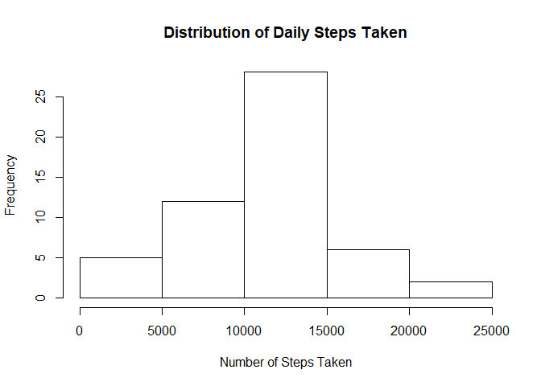

```r
daily_data <- step_data %>%
    group_by(date) %>%
    summarize(daily_steps = sum(steps))



hist(daily_data$daily_steps
     ,xlab = "Number of Steps Taken"
     ,ylab = "Frequency"
     ,main = "Distribution of Daily Steps Taken")
```

```r
print(paste0("The mean number of steps per day is ", mean(daily_data$daily_steps,na.rm = TRUE)))
```

```
## [1] "The mean number of steps per day is 10766.1886792453"
```

```r
print(paste0("The median number of steps per day is ", median(daily_data$daily_steps, na.rm = TRUE)))
```

```
## [1] "The median number of steps per day is 10765"
```

## What is the average daily activity pattern?

We create another dataframe, this time looking at what happens for a given interval across all days. We then create a lineplot showing how the average number of steps changes per interval as the a day progresses.

We also then can find what interval has, on average, the largest number of steps every day.

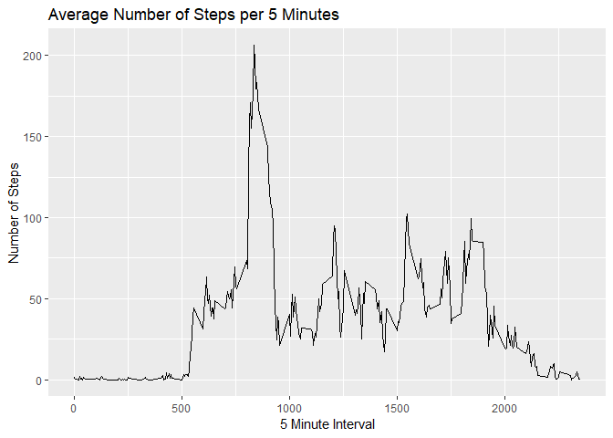

```r
interval_summary <- step_data %>%
    group_by(interval) %>%
    summarise(interval_mean_steps = mean(steps, na.rm = TRUE))

ggplot(interval_summary, aes(x = interval, y = interval_mean_steps)) +
    geom_line() +
    labs(title = "Average Number of Steps per 5 Minutes"
         ,y = "Number of Steps"
         ,x = "5 Minute Interval")
```

```r
print(paste0("The interval with the largest average number of steps across all days is  interval ",interval_summary$interval[which.max(interval_summary$interval_mean_steps)]))
```

```
## [1] "The interval with the largest average number of steps across all days is  interval 835"
```

## Imputing missing values

We notice that there are some entries where the step value is NA. We can impute this value, or assign a value you to it based on some analysis, in many different ways.

I believe the best way to impute a given missing step value is to look at the mean step value for the interval across all days and rounding it to an integer (since you can’t take a fraction of a step).

To see the impact of imputing these step counts, we can look at a histogram and some summary statistics for the imputed data and compare it to unimputed data.

```r
paste0("The steps column has ", sum(is.na(step_data$steps))," NA values.")
```

```
## [1] "The steps column has 2304 NA values."
```

```r
paste0("The date column has ", sum(is.na(step_data$date))," NA values.")
```

```
## [1] "The date column has 0 NA values."
```

```r
paste0("The interval column has ", sum(is.na(step_data$interval))," NA values.")
```

```
## [1] "The interval column has 0 NA values."
```

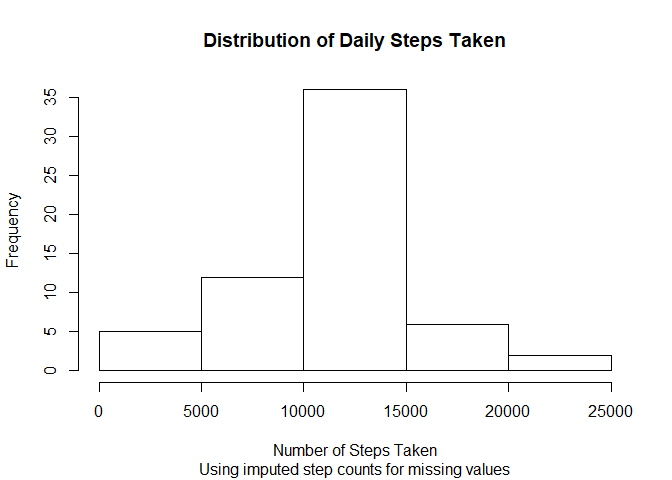

```r
imputed_daily_data <- step_data %>%
    group_by(interval) %>%
    mutate(interval_mean_steps = mean(steps, na.rm = T)
           ,imputed_steps = case_when(is.na(steps) ~ round(interval_mean_steps,0)
                                      ,!is.na(steps) ~ as.double(steps))) %>%
    select(-interval_mean_steps) %>%
    group_by(date) %>%
    summarise(imputed_daily_steps = sum(imputed_steps))

hist(imputed_daily_data$imputed_daily_steps
     ,xlab = "Number of Steps Taken"
     ,ylab = "Frequency"
     ,main = "Distribution of Daily Steps Taken"
     ,sub = "Using imputed step counts for missing values")
```

```r
print(paste0("The mean number of steps per day using the imputed step count for missing data is ", mean(imputed_daily_data$imputed_daily_steps,na.rm = TRUE)))
```

```
## [1] "The mean number of steps per day using the imputed step count for missing data is 10765.6393442623"
```

```r
print(paste0("The median number of steps per day using the imputed step count for missing data is ", median(imputed_daily_data$imputed_daily_steps, na.rm = TRUE)))
```

```
## [1] "The median number of steps per day using the imputed step count for missing data is 10762"
```

From this we see that there’s around 10 more days with a daily step count between between the 10,000 and 15,000 step count. We also see that the mean and median are still pretty close to the unimputed data. It is important to note that depending on your imputation method there could be a much different impact.

## Are there differences in activity patterns between weekdays and weekends?

Finally, we want to see if there are any differences between weekdays and weekends. To do this, we first create a new column on the dataset to indentify if a given date falls on a weekday or a weekend. and then compute the average number of steps for each interval on weekdays and weekends.

After constructing a dataset that takes care of the above, we plot the graphs for weekend and weekday next to each other. From this we can see some differences. For example on weekdays the step count has a spike earlier than on weekends, and it kind of looks like on weekends the step count per interval is a bit more consistent than on weekdays.

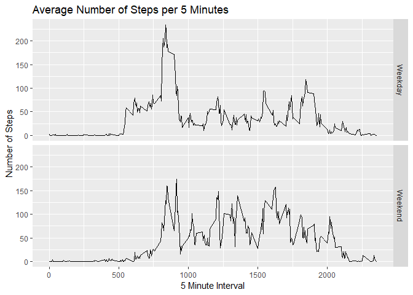

```r
weekday_data <- step_data %>%
    mutate(weekday_ind = case_when(weekdays(date) %in% c("Saturday","Sunday") ~ "Weekend"
                                   ,TRUE ~ "Weekday")) %>%
    group_by(weekday_ind, interval) %>%
    summarise(step_mean = mean(steps, na.rm = T))

ggplot(weekday_data, aes(x = interval, y = step_mean)) +
    geom_line() +
    facet_grid(weekday_ind ~ .) +
    labs(title = "Average Number of Steps per 5 Minutes"
         ,y = "Number of Steps"
         ,x = "5 Minute Interval")
```